# IE5

Ben Kaufman

Vic Chan

Ziwei Zhang

# Introduction

In this paper we will be focusing around the impact of a worker’s sex on their hourly wage. The dataset we are using for this project is a random sample of 534 people from the 1985 Current Population Survey (CPS) which contains cross-sectional data of potential determinants of wage. In this assignment we will use several statistical techniques we have acquired from our study combined with some real-world knowledge to explore our dataset.

# Data Definitions

- *EDUCATION* : Number of years of education
- *SOUTH* : Indictor variable if a person is from the south or not
  0. Not From South
  1. From South
- *SEX* : Categorical variable indiciting whether one was male or female
  0. Male
  1. Female
- *EXPERIENCE* : Number of years of work experience
- *UNION* :
  0. Not in a Union
  1. In a Union
- *WAGE* : Wage earned per hour
- *AGE* : Age in year
- *RACE* : Categorical variable indiciting ones race
  1. Other
  2. Hispanic
  3. White
- *OCCUPATION* : Categorical variable indiciting ones occupation
  1. Management
  2. Sales
  3. Clerical
  4. Service
  5. Professional
  6. Other
- *SECTOR* : Categorical variable indiciting ones sector
  0. Other
  1. Manufacturing
  2. Construction
- *MARRIED* : Categorical variable indiciting ones marriage status
  0. Unmarried
  1. Married

# Background Information on the Wage Gap

Something that comes to mind when thinking of the determinants of wage is a person’s level of education. Loosely speaking, one would expect that the higher your level of education, the higher your hourly wage should be. There is some empirical evidence behind this claim. If we look at data from the US BLS Annual Demographic Supplement of the CPS from 2013 [3] we find that this is generally true for those above the age of 25. Also, interestingly, if we pay close attention to the scales of each axis, we find that on average, controlling for education and sex, men make more than women on average.

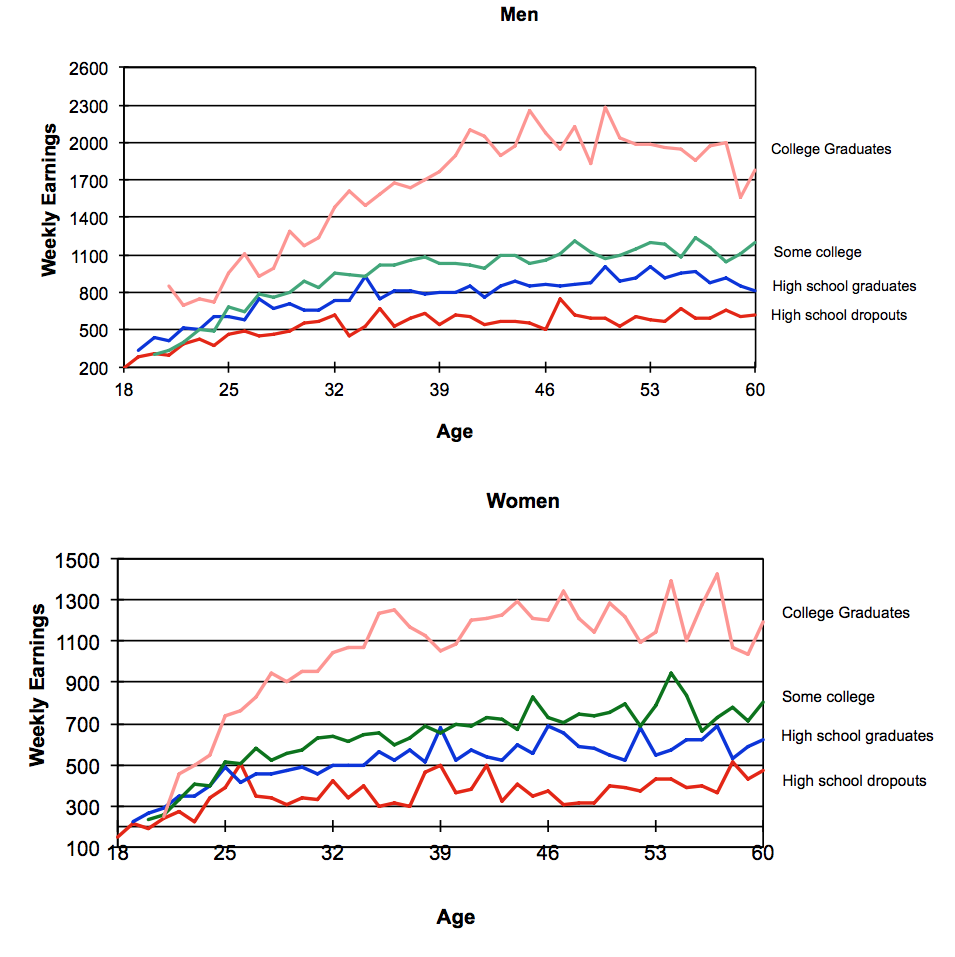

In this study we will not be looking numerically at the data shown above, instead we will use it qualitatively for some intuition and partial justification for adding education into our multiple linear regression model.

# Scatterplot Matrix

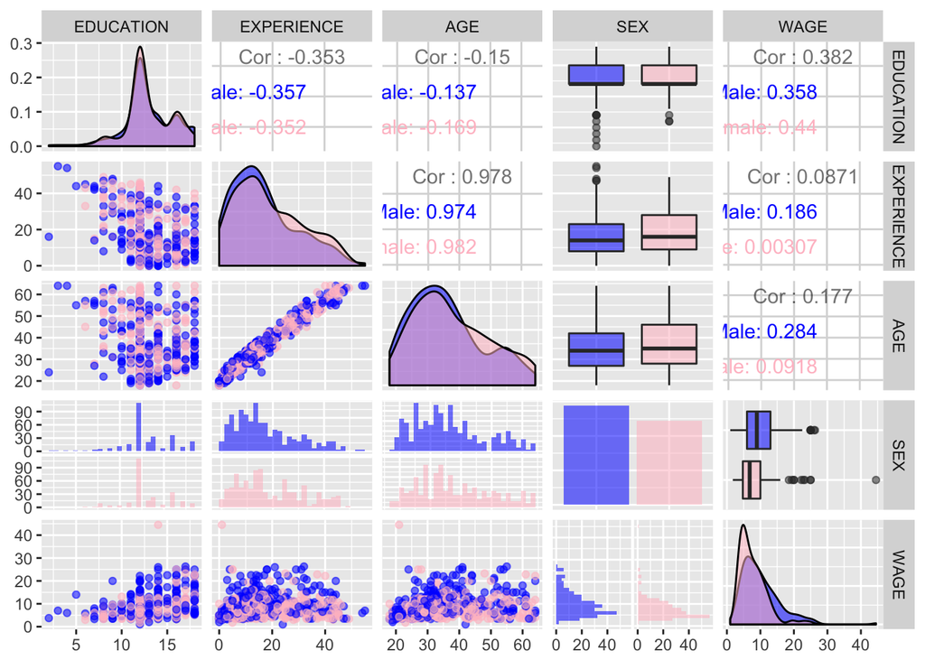

The dataset we chose has many factors and only a couple of continuous variables. In the figure above we only use a subset of the variables from our entire dataset. A few things pop out from the scatterplot matrix. Starting from the top left cell and looking down the main diagonal we see that men and women have similar distributions of levels of education, years of experience and age. We also see that our dataset contains about the same amount of men and women, 289 and 245 respectively. Looking at the bottom right cell we find that men and women have dissimilar wage distributions. In the box plot above this cell we clearly see that the median wage for men is higher than that of women. When looking at the marginal plots in the lower triangular region of the scatterplot matrix the two plots that stick out the most are those comparing *Age* vs. *Experience* and *Wage* vs. *Education*. We will explore these relationships more deeply and create models using statistical reasoning combined with real-world knowledge in attempt to explain wage gaps between men and women.

# Model 1: WAGE ~ EDUCATION + SEX

First, we would like to explore the existence of a wage gap when controlling for years of education.

$$\begin{align*}
M1: E(Wage|Education, Sex) &= \beta_{0,1} + \beta_{1,1} Education + \beta_{2,1} Sex
\end{align*}$$

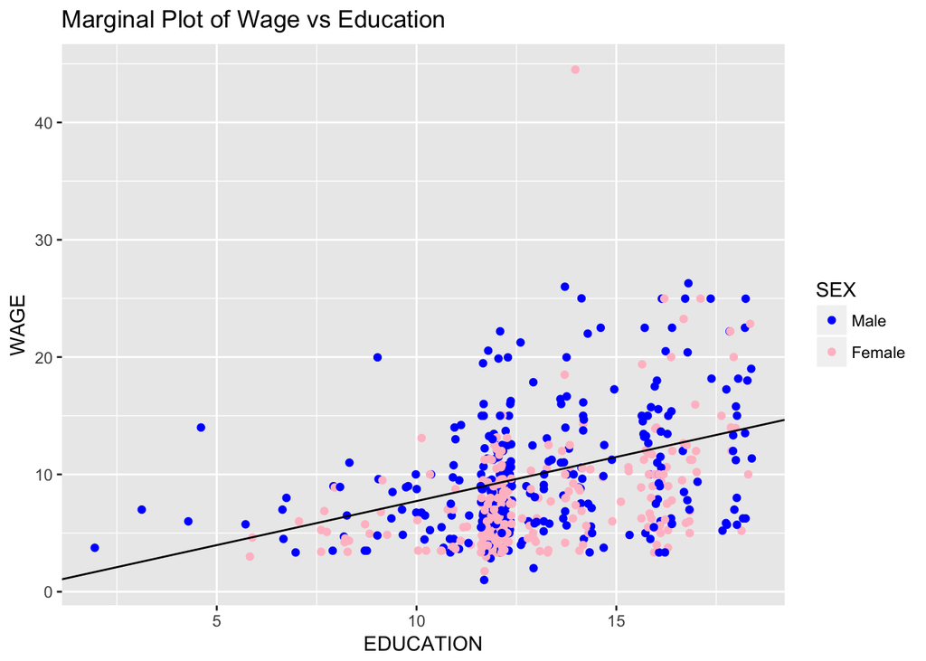

As we see in the figure above the model describes the positive relationship between *Wage* and *Education* as shown by the slope of the line, $\beta_{1,1} = 0.75128 > 0$. We also note that the confidence interval for this parameter is roughly (0.6, 0.9) which does not contain zero meaning that this parameter is significant. Under this model we also see that a wage gap between men and women is present. It is estimated that a women of will make $2.12 less ($\beta_{2,1}=-2.124$) per hour than a man of similar education level. We note that the confidence interval for this estimate is (-2.915, -1.333) which again, does not contain zero and is significant. To wrap up this section, we will remember for the purposes of comparison later on that the $R^2$ for our “baseline” model is 0.1884.

# Model 2: WAGE ~ EDUCATION + SEX + SEX:EDUCATION

A question that seems reasonable is, does the wage gap between men and women decrease as the level of education for both groups increases? In order to explore this we create a new model with an interaction term between *Sex* and *Education*.

$$\begin{align*}
M2: E(Wage|Education, Sex) &= \beta_{0,2} + \beta_{1,2} Education + \beta_{2,2} Sex + \beta_{3,2} Sex:Education
\end{align*}$$

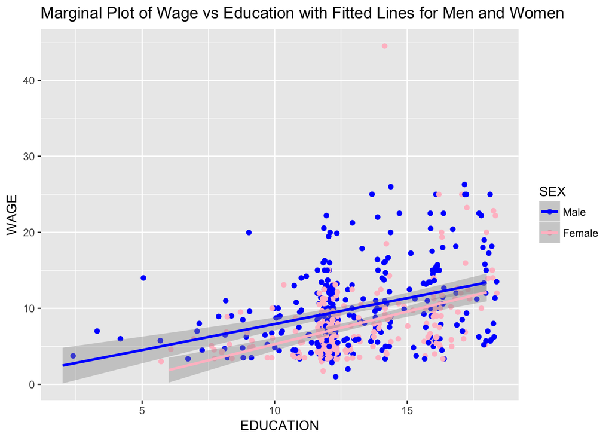

Above we can see the the fitted lines between men and women seem to have a different intercept but have roughly the same slope. To hammer this point down we find that the estimated coefficient for the interaction term has a confindence interval of (-0.136, 0.481) which contains zero and cannot be effectively relied upon. All of this information supports the argument that wage gap between men and women **does not** decrease as the number of years of education increases.

# Added Variable Plot: M1 and Experience

As it stands our model only uses *Sex* and *Education* as predictors. As we know from the real world, your wage might be related to the amount of experience you have had in a job. For example, more exclusive jobs normally pay more and the reason they may be exclusive is because they may require x years of experience. Another reason is because job experience implies a gain in on-the-job-training which means that you should be more productive and should thus be paid more. This allows us to hypothesize that your wage will depend upon the amount of experience you’ve had, more specifically, we would believe that your wage should increase with your level of experience. In order to justify adding this variable to our model we will create an added variable plot.

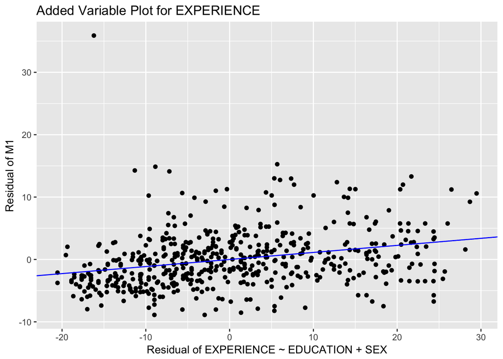

# Model 3: WAGE ~ EDUCATION + SEX + EXPERIENCE

$$\begin{align*}
M3: E(Wage|Education, Sex, Experience) &= \beta_{0,3} + \beta_{1,3} Education + \beta_{2,3} Sex + \beta_{3,3} Experience \\
\end{align*}$$

Looking at our new model we look back to our original question which is, does the wage gap between men and women still exist? According to M3 we found that the wage gap between men and women increased after we accounted for experience from $2.12 per hour to $2.34 per hour which opposed our intuitions. As usual, we found that the confidence interval for $\beta_{2,3}$ is (-3.0999,-1.5753) which does not contain zero and the p-value is << 0. Lastly, for the purposes of comparison to previous and future models the $R^2$ of this model is 0.2532.

# Added Variable Plot: M3 and Age

Another variable in our data set we may want to consider is *Age*. *Age* may not directly influence your wage but it may influence other variables which directly influence your wage. This idea combined with our observation of high correlation between *Age* and *Experience* from the marginal plot in our scatterplot matrix suggests that this variable may be collinear variables that already exist in our model. To further examine this we create an added variable plot.

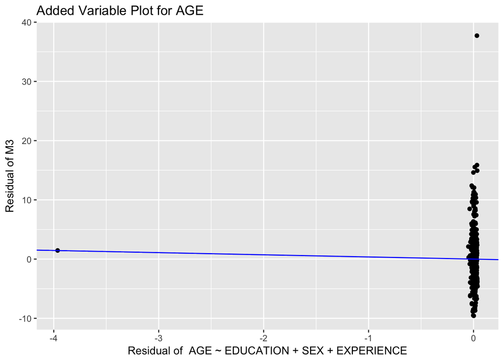

As we can see from the added variable plot adding *Age* to our model is not very helpful because a line might describe the data well if the outlier did not exist but the slope would infinite. In this case we see that the fitted line does not in fact describe the data well because of the outlier. The confidence interval for the slope is (-2.56,1.83) which contains zero so we cannot assert that the slope is non-zero. Futhermore, our $R^2$ is 0.0002036 which is nearly zero meaning that variance that age would explain is for the most part already explained by variables in the model.

# Collinearity

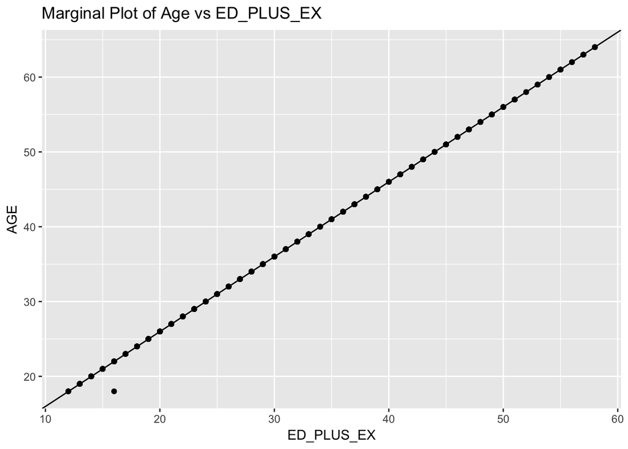

If we look at the fitted model we essentially see that $Age=6+1*(Education+Experience)$ which tells us something we should already know in the US. In the US most people begin their schooling, enter first grade, at around age 6. What we find is that for the rest of people’s lives in our dataset people are either in school or working which makes sense because most people retire at 65 and the oldest person is 64 years old. To conclude our discussion of *Age* as a predictor we have decided to not use it in our model because it would interfere with our existing variables in our model. However, we will note that since we have made this choice our estimate of the wage gap between the sexes may be underestimated because the amount of experience you have may be influenced by your sex; in this case women may have less experience than men because they may have to take time off from work to raise children. Since this is a subtle point and there is no data to support time off between sexes in this case there will be no further discussion and this type of analysis will be reserved for studies where this effect is more relevant.

# Power Transformations

In order to find a better fit to the data we can try to add some non-linearity to our model without making our model non-linear. We do this using power transformations on the predictors and then on the response.

The results from the power transformation suggests that we should not transform *Education* and that it is advisable to take the square root of *Experience* once we have adjusted the domain of *Experience* to be strictly greater than zero. In the real world this may be justified by diminishing returns to experience. We can then use the Box-Cox Transformation to transform our response variable.

Since our suggested value of $\lambda$ from the transformation is zero we will take the log of our response variable in our new model.

## Quickly Reaffirming Assumptions Made Before Power Transformations

The first thing we tried to justify in our study was that there was non-significant interaction between *Education* and *Sex* in model 2. This may have not been the case had we used *log(Wage)* as our response. Here we have made a model which models the *log(Wage)* by *Education* and *Sex* and the interaction between *Sex* and *Education* and find that the interaction term is not really significant. This means that in our future models which use *log(Wage)* as the response we don’t have to include this interaction term because the 95% confindence interval on the interaction term contains zero (-0.000732, 0.062341). Visually we can see this in a graph similar to **Marginal Plot of Wage vs Education with Fitted Lines for Men and Women**. Below the slopes of the regression lines for men and women are about the same.

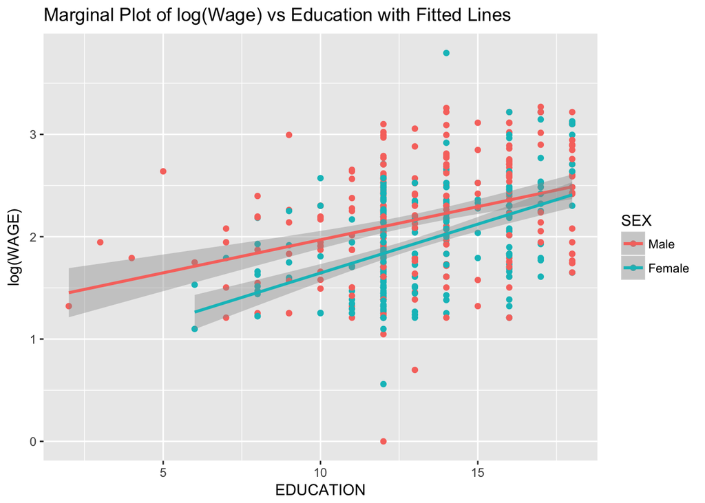

The other procedure we conducted was the choice to add *Experience* to our model. Here we will show that even when using the *log(Wage)* as our response we are justified in adding it to our model.

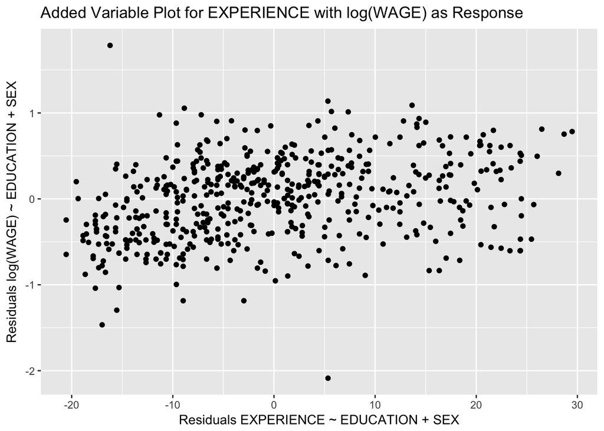

The figure above is an added variable plot for Experience added to model 1 where the response for model 1 is *log(Wage)* instead of *Wage*. We find that the remaining variation explained is 9.517% which is an increase from roughly 8% from our findings in our initial added variable plot.

# Model 4: log(WAGE) ~ EDUCATION + SEX + sqrt(EXPERIENCE+1)

$$\begin{align*}
M4: E(log(Wage)|Education, Sex, Experience) &= \beta_{0,4} + \beta_{1,4} Education + \beta_{2,4} Sex + \beta_{3,4} \sqrt{Experience}
\end{align*}$$

In our new transformed model our definition of the wage gap between men and women changes. Our interpretation of the wage gap now becomes the percentage difference in wage between men and women adjusting for all other variables. In model 4 we find that adjusting for *Education* and our new interpretation of *Experience* women make 25.79% less than men. As usual, for reference our $R^2$ for M4 is 0.2894 however we cannot compared this directly to the $R^2$ values of our previous models since we have taken the log.

While testing our models we found that in M4 we have finally solved our problem of non-constant variance (heteroscedasticity) which violates an assumption of linear models. We see this in the plots of residuals versus fitted values. In the residuals versus fitted values plot for model 3 we see an example of a right-opening megaphone:

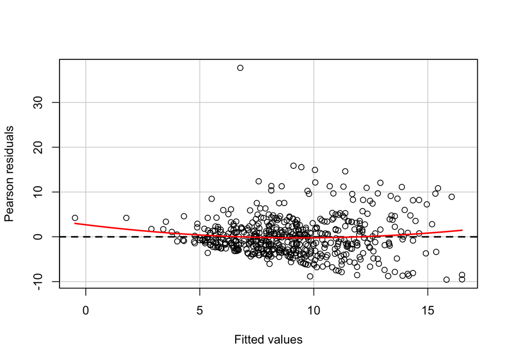

However, in model 4 we find there is constant variance which means our model is valid.

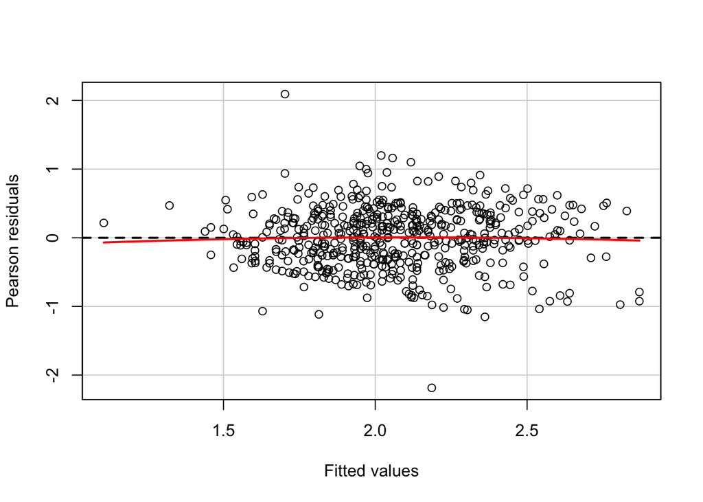

## Mincer Earnings Function

At this point our model looks very similar to a prominent econometric model called the Mincer Earnings Function. The model is defined roughly as follows in [1].

$$\begin{align*}
MEE: E(Wage|Education, Sex, Experience) &= log(w_0) + a Education + b Experience - \\
c Experience^2 + \text{Other Variables}
\end{align*}$$

In this case $w_0$ is the average wage a person in the reference group would expect to make. The coefficient *a* is interpretted as the average rate of return to schooling assuming workers are of equal ability. The coefficients *b* and *c* estimate the growth in earnings from an additional year of experience and are only greater than zero if it is assumed a worker invests in on-the-job-training. In short, since this isn’t an economics paper, the squared term for experience comes from the idea that real post school investment in human capital decreases (assumed to be linearly decreasing) over the lifespan of the worker. This and the derivation of the Mincer Earnings Function is further described in [2].

For our purposes we will add *Sex* to our model.

What we find is that our $R^2$ hardly increases compared to our model 4, the power transformed model which uses the square root of experience, from 0.2894 to 0.2968. What we also find is that *c* is significant and explains about 3% of the remaining variance compared to just using experience alone. The main difference between model 4 and the Mincer Earnings Function is the interpretation of the effect of experience on wages. If we look at a graph the change in hourly wage due to experience versus the amount of years of expereince the shape of the these graphs differs between these models as shown in the figure below. What ends up happening is that the rate of return to schooling remains about the same at 0.097740 in M4 and 0.0912936 in MEF and the wage gap remains almost exactly the same at about -0.25.

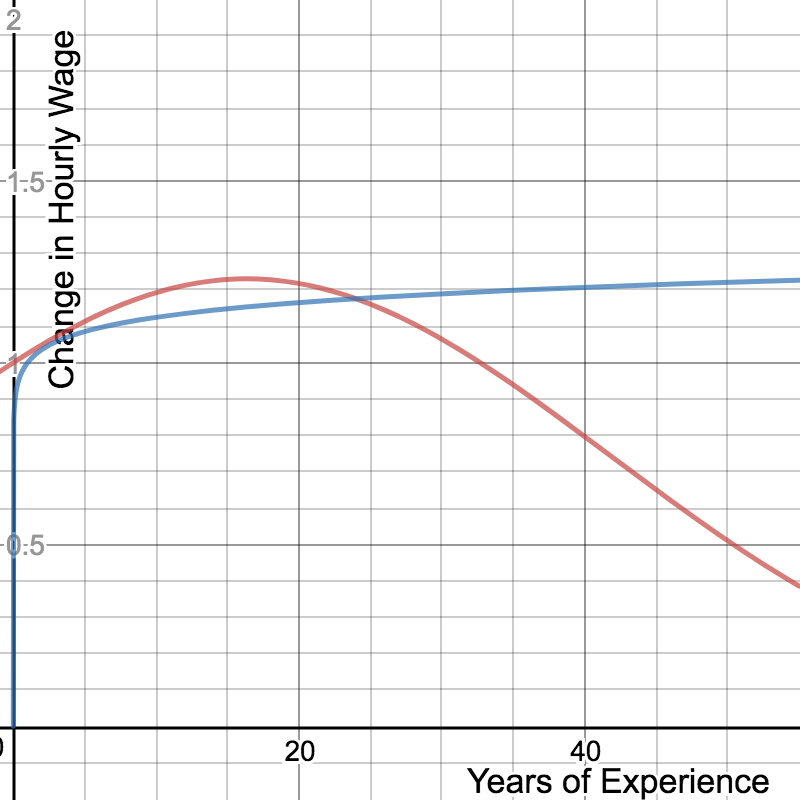

Since our models are very similar and the justification for the Mincer Earnings Function was not founded by us we will use model 4 as the base model for expansion in the rest of this study.

# Model 5: log(WAGE) ~ EDUCATION + SEX + OCCUPATION + sqrt(EXPERIENCE+1)

$$\begin{align*}
M5: E(log(Wage)|\textbf{X}) &= \beta_{0,5} + \beta_{1,5} Education + \beta_{2,5} Sex + \beta_{3,5} \sqrt{Experience} + \beta_{4,5} Management + \beta_{5,5} Sales + \\
& \beta_{6,5} Clerical + \beta_{7,5} Service +\beta_{8,5} Professional
\end{align*}$$

Now that we are accounting for a person’s *Education* and *Experience* we can now try to explore the effect of a person’s *Occupation* on wage. The justification for adding *Occupation* into our model is that even after you account for all other variables in our model, a person’s occupation may influence their wage. One way to think about this is that two jobs may require the same levels of education and experience but may incur different levels of risk of physical harm on the worker. Economic theory would suggest that the person who incurs more risk should make proportionally more money. This is just an example of how the type of occupation one takes can influence wage while controlling for our other variables. In model 5 we explore the main effects model.

Under this model we find that women make -22.7408% less than men while controlling for all of these factors. We also note that our $R^2$ increased to 0.3346 and our RSE slightly decreased to 0.4338.

# Model 6: log(WAGE) ~ EDUCATION + SEX * OCCUPATION + sqrt(EXPERIENCE+1)

$$\begin{align*}
M6: E(log(Wage)|\textbf{X}) &= \beta_{0,6} + \beta_{1,6} Education + \beta_{2,6} Sex + \beta_{3,6} \sqrt{Experience} + \beta_{4,6} Management + \beta_{5,6} Sales + \\
& \beta_{6,6} Clerical + \beta_{7,6} Service + \beta_{8,6} Professional + \\
& \beta_{9,6} Sex:Management + \beta_{10,6} Sex:Sales + \beta_{11,6} Sex:Clerical + \\
& \beta_{12,6} Sex:Service + \beta_{13,6} Sex:Professional \\
\end{align*}$$

In model 6 we explore the possiblity that the effect of you occupation on your wage is different for men and women. If we look at the analysis of variance table for this model we find that the the interaction term between *Sex* and *Occupation* is significant.

```
## Analysis of Variance Table
##
## Response: log(WAGE)
##                 Df Sum Sq Mean Sq  F value    Pr(>F)
## EDUCATION        1 21.481 21.4807 116.2308 < 2.2e-16 ***
## tranEXPERIENCE   1 12.713 12.7133  68.7912 9.436e-16 ***
## SEX              1  8.765  8.7654  47.4291 1.651e-11 ***
## OCCUPATION       5  6.711  1.3421   7.2620 1.373e-06 ***
## SEX:OCCUPATION   5  2.675  0.5351   2.8953    0.0137 *
## Residuals      520 96.102  0.1848
## ---
## Signif. codes:  0 '***' 0.001 '**' 0.01 '*' 0.05 '.' 0.1 ' ' 1
```

Another way to try to visualize this is by looking at the mean wages for men and women without controlling for *Education* and *Experience.*

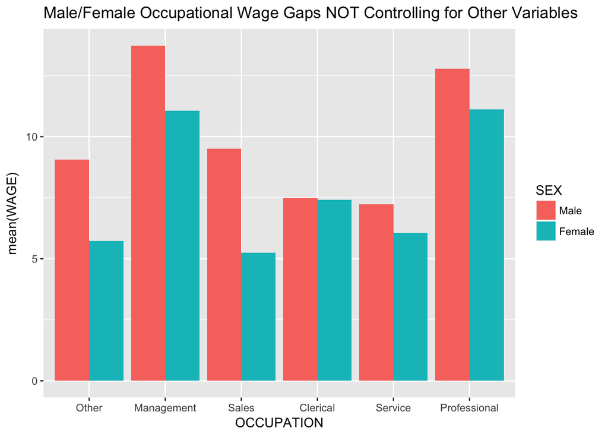

When controlling for education and experience we find the following wage gaps between men and women. Negative percentages should be interpretted as the percentage amount of wage females make less than men while controlling for education and experience.

Wage Gaps for Females Compared to Males

| Occupation | Male/Female Wage Gap | # Men | # Women |
| --- | --- | --- | --- |
| Other | -43.6% | 126 | 30 |
| Management | -12.9% | 34 | 21 |
| Sales | -49.1% | 21 | 17 |
| Clerical | -6.3% | 21 | 76 |
| Service | -21.0% | 34 | 49 |
| Professional | -10.5% | 53 | 52 |

The occupation-specific wage gaps are interesting. As we would expect the wage gap in *Occupation* Other is very large since it is as if we are not controlling for *Occupation* at all. In Management, Professional and Clerical jobs we find that the wage gap between men and women drastically decreases. In the Service industry we find that the wage gap is at about the same level as before we controlled for *Occupation*. However, in the Sales occupation we found that the wage gap between men and women is massive, women make almost 50% less than men of the same level of education and experience. Right now we cannot offer an explanation for this discrepancy.

Looking back at the results from the analysis of variance we found that overall the interaction between *Sex* and *Occupation* is signifcant enough to include in our model. When we looked at each of the significances and confidence intervals for each occupation-specific wage gap we found that they depend on the significance of the reference variable in our model to some extent. This is why we included the number of men and women in each occupation in our table so you can get a sense of what these wage gap numbers are calculated from.

Finally, to conclude model 6, we found that our $R^2$ increased to 0.3526 and our $RSE$ decreased to 0.4299.

# Model 7: log(WAGE) ~ EDUCATION + SEX + sqrt(EXPERIENCE+1) + OCCUPATION + UNION

$$\begin{align*}
M7: E(log(Wage)|\textbf{X}) &= \beta_{0,7} + \beta_{1,7} Education + \beta_{2,7} Sex + \beta_{3,7} Experience + \beta_{4,7} Management + \beta_{5,7} Sales + \\
& \beta_{6,7} Clerical + \beta_{7,7} Service +\beta_{8,7} Professional + \beta_{9,7} Union
\end{align*}$$

In our final model we would like to account for union status. This is a main effects model which means we are going against model 6 because if we were to try to estimate the occupation-specific wage gap accounting for union status we would not have enough data in each occupation to make a reasonable claim. In the table below we can see that some occupations hardly have any unionized members. When we break it down by *Sex* to estimate the occupation-specific wage gap this problem only gets worse.

Number of Men and Women in Each Occupation by Union Status

| Occupation | Union Status | Number of People |
| --- | --- | --- |
| Other | Non-Unionized | 112 |
| Other | Unionized | 44 |
| Management | Non-Unionized | 52 |
| Management | Unionized | 3 |
| Sales | Non-Unionized | 37 |
| Sales | Unionized | 1 |
| Clerical | Non-Unionized | 89 |
| Clerical | Unionized | 8 |
| Service | Non-Unionized | 66 |
| Service | Unionized | 17 |
| Professional | Non-Unionized | 82 |
| Professional | Unionized | 23 |

In model 7 we find that women on average earn 20.7% less than men when controlling for all the variables in model 7. This claim is significant because the confidence interval for the coefficient on *Sex* does not contain zero (-0.289 -0.126). Also, we find that unionized workers make on average 20.8% more than non-unionized workers when controlling for all other variables. This claim is also significant as supported by the confidence interval of the *Union* coefficient not containing zero (0.109 0.308). Something to note about the “Union Gap” is that it is overestimated because it only considers your wage and not your wage net of union dues. Lastly, our $R^2$ increased to 0.3556 compared to model 5 and our $RSE$ decreased to 0.4273.

# Conclusion

# Caveats

Here are some of our final thoughts we had while doing this project:

- Our $R^2$ is fairly low and our $RSE$ is pretty high in all of our models. Since the focus of our project is to try estimate the wage gap rather than predict wages we can accept errors of about 40% in our model.
- In the future we might want to use the entire CPS wage dataset rather than a random sample.
- One major area in which this paper is lacking is in the application of causal inference. When we add variables to our model we aren’t considering the effects of any potential mediator variables like occupation.

# References

1. Borjas, George J. *Labor Economics.* 7th ed. Boston: McGraw-Hill/Irwin, 2005.
2. Polachek, Solomon W. “Earnings Over the Life Cycle: The Mincer Earnings Function and Its Applications.” *Foundations and Trends in Microeconomics* 4, no. 3 (November 2007): 14-20. doi:10.1561/0700000018.
3. U.S. Bureau of Labor Statistics, *Annual Demographic Supplement of the Current Population Surveys*, 2013
4. Weisberg, Sanford. *Applied Linear Regression*. 4th ed. New York: John Wiley & Sons, 2014.